# My First Notebook MDA2024

## 4.3. Bar Plot

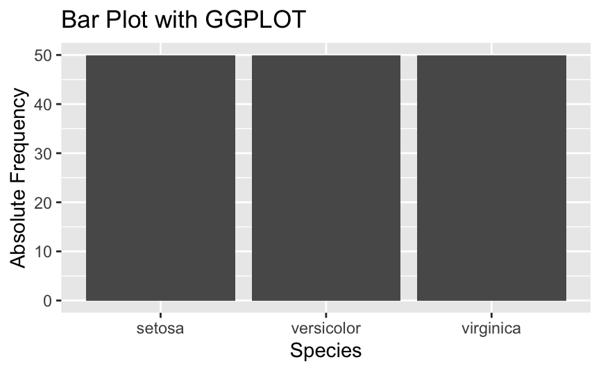

```r
ggplot(data = X) +
  geom_bar(mapping = aes(Species)) +
  ggtitle("Bar Plot with GGPLOT") +
  ylab("Absolute Frequency")
```

# 5. Use the mpg data (mpg Fuel economy data from 1999 to 2008 for 38 popular model of cars)

A data frame with 234 rows and 11 variables:

- *manufacturer* brand name
- *model* model name
- *displ* engine displacement, in litres (power of the engine)
- *year* year of manufacture
- *cyl* number of cylinders
- *trans* type of transmission
- *drv* the type of drive train, where f = front-wheel drive, r = rear wheel drive, 4 = 4wd
- *cty* city miles per gallon (km per liter in town)
- *hwy* highway miles per gallon (km per liter in highway)
- *fl* fuel type
- *class* “type” of car

```r
Y <- mpg
```

```r
summary(Y)
```

```
 manufacturer          model               displ
 Length:234         Length:234         Min.   :1.600
 Class :character   Class :character   1st Qu.:2.400
 Mode  :character   Mode  :character   Median :3.300
                                       Mean   :3.472
                                       3rd Qu.:4.600
                                       Max.   :7.000
      year           cyl           trans
 Min.   :1999   Min.   :4.000   Length:234
 1st Qu.:1999   1st Qu.:4.000   Class :character
 Median :2004   Median :6.000   Mode  :character
 Mean   :2004   Mean   :5.889
 3rd Qu.:2008   3rd Qu.:8.000
 Max.   :2008   Max.   :8.000
     drv                 cty             hwy
 Length:234         Min.   : 9.00   Min.   :12.00
 Class :character   1st Qu.:14.00   1st Qu.:18.00
 Mode  :character   Median :17.00   Median :24.00
                    Mean   :16.86   Mean   :23.44
                    3rd Qu.:19.00   3rd Qu.:27.00
                    Max.   :35.00   Max.   :44.00
      fl               class
 Length:234         Length:234
 Class :character   Class :character
 Mode  :character   Mode  :character
```

```r
head(Y)
```

| manufacturer | model | displ | year | cyl | trans | drv | cty | hwy | fl | class |
| --- | --- | --- | --- | --- | --- | --- | --- | --- | --- | --- |
| audi | a4 | 1.8 | 1999 | 4 | auto(l5) | f | 18 | 29 | p | compact |
| audi | a4 | 1.8 | 1999 | 4 | manual(m5) | f | 21 | 29 | p | compact |
| audi | a4 | 2.0 | 2008 | 4 | manual(m6) | f | 20 | 31 | p | compact |
| audi | a4 | 2.0 | 2008 | 4 | auto(av) | f | 21 | 30 | p | compact |
| audi | a4 | 2.8 | 1999 | 6 | auto(l5) | f | 16 | 26 | p | compact |
| audi | a4 | 2.8 | 1999 | 6 | manual(m5) | f | 18 | 26 | p | compact |